# Concentration

19 juin 2023

## Entropie de la concentration

## Intuition

Données Eurostat :

```
##        AT    BE    BG     CZ     DE    DK
## C10 71924 85083 82510 101575 591468 54896
## C11  9319  9814 13298  15301  71327  4523
## C13  8665 17329 12914  25983  73448  3951
## C14  6212  3495 99974  25717  35275  1611
```

La **diversité** des secteurs dans chaque pays considère les colonnes du tableau.

Les lignes du tableau décrivent la diversité des pays dans lesquels chaque secteur est distribué, qu’on appellera sa **valence** (ubiquité est une alternative).

La valence est peu traitée en écologie parce que les sites sont des généralement des échantillons.

Exception : Levins (1968), qui définit la largeur de la niche écologique.

## Questions similaires

Biodiversité :

- Nombres d’arbres par espèces dans un habitat forestier : biodiversité.
- Nombres d’arbres par habitat pour une espèce : valence.

Economie :

- Nombre d’employés par secteur industriel dans un pays : diversité = contraire de la spécialisation.
- Nombre d’employés par pays pour un secteur : valence = contraire de la concentration spatiale.

## Conséquences

Tout ce qui a été dit et fait sur la diversité est valable pour la valence en transposant le tableau de données :

- La valence s’exprime en nombre effectifs de pays occupés par un secteur ;
- La valence peut être décomposée ;
- Elle peut être transformée en concentration spatiale, par exemple en calculant (Nb Pays - valence) / (Nb Pays - 1)

## Exemple

Valence des secteurs C10 (Manufacture de produits alimentaires, en vert), C20 (Manufacture de produits chimiques, en bleu), et de l’industrie entière (en noir).

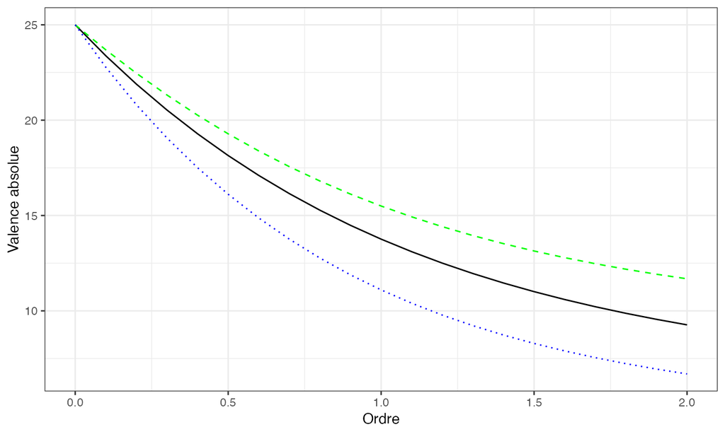

## Exemple

Concentration absolue des secteurs C10 (Manufacture de produits alimentaires, en vert), C20 (Manufacture de produits chimiques, en bleu), et de l’industrie entière (en noir).

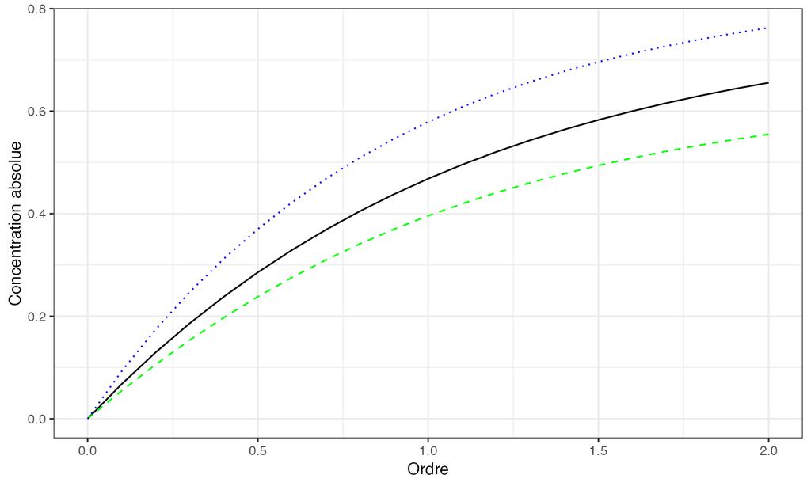

## References

Levins, Richard. 1968. *Evolution in Changing Environments: Some Theoretical Explorations*. Princeton University Press.